# Deconvolution of bulk expression data

Zhiyuan Hu

2019/11/25

# 1 Summary

# 2 Single cell data

```r
load("../../scFT-paper_rds/20191125background_deconvolution_scRNAseqData.rdata")
```

# 3 Select Markers

We selected the representative marker genes to denote the transcriptomic signatures of the five FTE cell subtypes.

```r
marker.C3 <- markers2[markers2$cluster == "C3" & markers2$logFC > 1.79, ]
marker.C4 <- markers2[markers2$cluster == "C4" & markers2$logFC > 1.5 & markers2$ratio2 < 0.3,]
marker.EMT <- markers2[markers2$cluster == "C8" & markers2$logFC > 2 & markers2$ratio2 < 0.2,]
marker.C10 <- markers2[markers2$cluster == "C10" & markers2$logFC > 2.5 & markers2$ratio2 < 0.2,]
marker.ciliated <- markers_sceset[markers_sceset$cluster == 9 & markers_sceset$logFC > 6 & markers_sceset$ratio2 < 0.1,]

markers <- list(C3 = marker.C3$gene,
                C4 = marker.C4$gene,
                EMT = marker.EMT$gene,
                C10 = marker.C10$gene,
                ciliated = marker.ciliated$gene)
```

## 3.1 Construct a scRNA-seq dataset for fresh FTE cells

```r
fresheset <- ExpressionSet(assayData = as.matrix(counts(fresh)),
                           phenoData = new("AnnotatedDataFrame",
                                           data=as.data.frame(fresh@colData)))
fresheset$cell.type <- NA
fresheset$cell.type[fresheset$Sample %in% secretory$Sample[secretory$clincluster_final == "C3"]] <- "C3" # differentiated
fresheset$cell.type[fresheset$Sample %in% secretory$Sample[secretory$clincluster_final == "C4"]] <- "C4" # KRT17 cluster
fresheset$cell.type[fresheset$Sample %in% secretory$Sample[secretory$clincluster_final == "C8"]] <- "EMT"
fresheset$cell.type[fresheset$Sample %in% secretory$Sample[secretory$clincluster_final == "C10"]] <- "C10" # cell cycle clusters
fresheset$cell.type[fresheset$clincluster == 9] <- "ciliated"

fresheset <- fresheset[,!is.na(fresheset$cell.type)]
table(fresheset$cell.type)
```

```
##
##      C10       C3       C4 ciliated      EMT
##       23      167      186      145       40
```

```r
fresh <- fresh[,match(colnames(fresheset), colnames(fresh))]
fresh$cell.type <- fresheset$cell.type
```

# 4 Data

The eset datasets are preprocessed by ‘20181028Prepare_datasets.rmd’

The signature matrix is actually the mean expression within one cluster after normalisation (non-log-space).

We read the TCGA, AOCS and OXO-PCR preprocessed data from a saved RData file.

```r
## TCGA data
eset <- readRDS("../../man_analysis3_20190724/R_deconvolution/rds/20181029TCGA_eset.rds")
exprs_tcga <- readRDS("../../man_analysis3_20190724/R_deconvolution/rds/20181029TCGA_exprs_nonlog.rds")

tcga <- SingleCellExperiment(assays = list(counts = eset@assayData$exprs),
                             colData = as.data.frame(pData(eset)))
logcounts(tcga) <- log2(calculateCPM(tcga) + 1)

eset$stage_dichotomized <- "early"
eset$stage_dichotomized[eset$clinical_stage%in% c("Stage IIIA","Stage IIIB","Stage IIIC","Stage IV")] <- "late"

eset$residual_disease1 <- NA
eset$residual_disease1[eset$tumor_residual_disease %in% c(">20 mm", "11-20 mm") ] <- "residual"
eset$residual_disease1[eset$tumor_residual_disease %in% c("No Macroscopic disease","1-10 mm") ] <- "no_residual"

## AOCS data
toteset <- readRDS("../../man_analysis3_20190724/R_deconvolution/rds/20181029_tothill_eset.rds")
exprs_tot <- readRDS("../../man_analysis3_20190724/R_deconvolution/rds/20181029_tothill_exprs_nonlog.rds")

pData(toteset)$OS <- FALSE
pData(toteset)$OS[pData(toteset)$patient.status == "D"] <- TRUE

toteset$histological.subtype2 <- "ser"
toteset$histological.subtype2[toteset$histological.subtype != "Ser"] <- "non-ser"
toteset$histological.subtype2 <- as.factor(toteset$histological.subtype2)

## OXO-PCR data
oxopcr_pre <- readRDS("../../../OXO_PCR/R/rds/OXO_PCR_Allsamples_2018Oct_PreChemo.rds")
oxopcr_info_pre <- readRDS("../../../OXO_PCR/R/rds/OXO_PCR_Allsamples_2018Oct_PreChemo_sampleInfo.rds")

# save.image("../../scFT-paper_rds/bulkExprData_forDeconvolution20191125.rdata", compress = T)
```

```r
load("../../scFT-paper_rds/bulkExprData_forDeconvolution20191125.rdata")

toteset$summarystage <- NA
toteset$summarystage[toteset$Stage %in% c("I","IA",  "IB" , "IC",  "IIA", "IIB" ,"IIC")] <- "early"
toteset$summarystage[toteset$Stage %in% c("III",  "IIIA", "IIIB", "IIIC", "IV" )] <- "late"

toteset$summarygrade <- NA
toteset$summarygrade[toteset$Grade %in% c(1)] <- "low"
toteset$summarygrade[toteset$Grade %in% c(2,3)] <- "high"
```

# 5 Select genes by PCA in TCGA data

```r
# we removed the marker genes with little dispersion in the bulk RNAseq data
pca_emt <- function(markers){
  markers_in <- intersect(markers, rownames(tcga))
  exprs_mat <- logcounts(tcga)[match(markers_in, rownames(tcga)), ,drop = F]

  ## scale
  exprs_mat <- t(exprs_mat)
  vars <- DelayedMatrixStats::colVars(DelayedArray(exprs_mat))
  exprs_mat <- sweep(exprs_mat, MARGIN=2, # We scale by the standard deviation, which also changes the centre.
             STATS=sqrt(vars), FUN="/",
             check.margin=FALSE) # divide by the square root of vars

  ## PCA
  pca <- prcomp(exprs_mat)

  emt_w <- pca$rotation[,1]
  emt_w <- emt_w[order(emt_w, decreasing = T)]

  emt_w
}
```

```r
## genes with too good correlations can go (i.e. cor > 0.8)
# cor(t(log1p(exprs_tcga)[new_markers$EMT,]))
new_markers <- list()

# new_markers$progenitor <- markers$progenitor
out <- pca_emt(markers = markers$C3)
new_markers$C3 <- names(out)[abs(out) > 0.2]

out <- pca_emt(markers = markers$C4)
new_markers$C4 <- names(out)[abs(out) > 0.2]

out <- pca_emt(markers = markers$EMT)
new_markers$EMT <- names(out)[abs(out) > 0.2]
# cor(t(log1p(exprs_tcga)[new_markers$EMT,]))

out <- pca_emt(markers = markers$C10)
new_markers$C10 <- names(out)[abs(out) > 0.2]

out <- pca_emt(markers = markers$ciliated)

new_markers$ciliated <- names(out)[abs(out) > 0.2]
new_markers$ciliated <- new_markers$ciliated[c(1,2,3,8,9,10,13,14)] # remove redundant genes by cor > 0.8
# str(new_markers)
```

```r
length(unlist(new_markers))
```

```
## [1] 52
```

There are 52 genes in total

```r
lapply(new_markers, length)
```

```
## $C3
## [1] 7
##
## $C4
## [1] 10
##
## $EMT
## [1] 12
##
## $C10
## [1] 15
##
## $ciliated
## [1] 8
```

# 6 BSEQ-sc: compute the reference matrix

```r
sig_matrix_new <- bseq_my(markers = new_markers)
## upper limit
quantile(sig_matrix_new, 0.99)
```

```
##      99%
## 760.5106
```

```r
sig_matrix_new[sig_matrix_new > quantile(sig_matrix_new, 0.99)] <- quantile(sig_matrix_new, 0.99) # average the too high value
```

```r
gc()
```

```
##             used   (Mb) gc trigger   (Mb) limit (Mb)  max used   (Mb)
## Ncells   6485768  346.4   12344715  659.3         NA   8379664  447.6
## Vcells 164840413 1257.7  453635876 3461.0      16384 452605823 3453.2
```

```r
rm(secretory)
rm(fresh)
rm(fresheset)
```

# 7 Deconvolution and survival analysis

## 7.1 Cibersort TCGA

Use the reference matrix to decompose TCGA data

```r
svr_fit_new <- cibersort_my(sig_matrix = sig_matrix_new, exprs_unlogged = exprs_tcga)
eset$EMT <- svr_fit_new[,"EMT"]
head(svr_fit_new)
```

```
##                        C3         C4        EMT       C10 ciliated P-value
## TCGA-61-1910-01 0.5724750 0.00000000 0.00000000 0.4275250        0   0.035
## TCGA-61-1728-01 0.0000000 0.70060618 0.00000000 0.2993938        0   0.054
## TCGA-09-1666-01 0.5369213 0.41554483 0.04753383 0.0000000        0   0.164
## TCGA-24-1469-01 0.1016413 0.04211087 0.00000000 0.8562478        0   0.024
## TCGA-04-1348-01 0.0000000 0.13762873 0.00000000 0.8623713        0   0.037
## TCGA-61-1917-01 0.1180248 0.00000000 0.18586864 0.6961066        0   0.388
##                 Correlation      RMSE
## TCGA-61-1910-01  0.42514760 0.9604260
## TCGA-61-1728-01  0.37780345 0.9551460
## TCGA-09-1666-01  0.22881423 1.1189966
## TCGA-24-1469-01  0.47347979 0.8898185
## TCGA-04-1348-01  0.41441058 0.9240683
## TCGA-61-1917-01  0.09979954 1.0876390
```

```r
# write.csv(svr_fit_new,"../../scFT-paper_rds/20191125TCGA_deconvolutionResults.csv")
```

### 7.1.1 Barplots

Barplots

```r
svr_fit_new_diff <- svr_fit_new[svr_fit_new[,1] > 0.5,]
svr_fit_new_diff <- svr_fit_new_diff[order(svr_fit_new_diff[,1], decreasing = F),]
svr_fit_new_krt <- svr_fit_new[svr_fit_new[,2] > 0.5,]
svr_fit_new_krt <- svr_fit_new_krt[order(svr_fit_new_krt[,2], decreasing = F),]
svr_fit_new_emt <- svr_fit_new[svr_fit_new[,3] > 0.5,]
svr_fit_new_emt <- svr_fit_new_emt[order(svr_fit_new_emt[,3], decreasing = F),]
svr_fit_new_cc <- svr_fit_new[svr_fit_new[,4] > 0.5,]
svr_fit_new_cc <- svr_fit_new_cc[order(svr_fit_new_cc[,4], decreasing = F),]
svr_fit_new_others <- svr_fit_new[!rownames(svr_fit_new) %in% c(rownames(svr_fit_new_diff),rownames(svr_fit_new_krt),
                                                               rownames(svr_fit_new_emt),rownames(svr_fit_new_cc)),]

plot.data <- data.frame(sample = rep(rownames(svr_fit_new), 5),
                        state = rep(c("Differentiated","KRT17","EMT","Cell cycle","Ciliated"), each = nrow(svr_fit_new)),
                        score = c(svr_fit_new[,1],
                                  svr_fit_new[,2],
                                  svr_fit_new[,3],
                                  svr_fit_new[,4],
                                  svr_fit_new[,5]))
plot.data$sample <- factor(plot.data$sample, levels = c(rownames(svr_fit_new_diff),rownames(svr_fit_new_krt),
                                                               rownames(svr_fit_new_emt),rownames(svr_fit_new_cc),
                                                        rownames(svr_fit_new_others)))
plot.data$state <- factor(plot.data$state, levels = c("Differentiated","KRT17","EMT","Cell cycle","Ciliated"))
# differentiated #A16BA3
# F6A000 KRT7
# FFDE00 EMT
# CC #4DD9FF
#F3A1B6 Ciliated
```

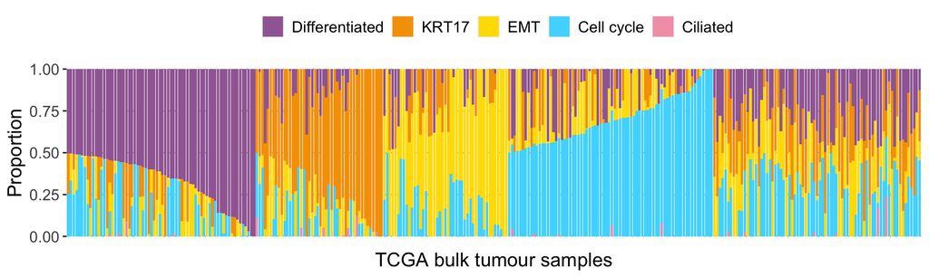

```r
ggplot(plot.data) + geom_bar(aes(y = score, x = sample, fill = state),
                           stat="identity") + theme_pubclean() +
  scale_fill_manual(values = c("#A16BA3","#F6A000","#FFDE00","#4DD9FF","#F3A1B6"),
                    breaks = c("Differentiated","KRT17","EMT","Cell cycle","Ciliated"),
                    labels = c("Differentiated","KRT17","EMT","Cell cycle","Ciliated")) +
  xlab("TCGA bulk tumour samples") + ylab("Proportion") +
  theme(axis.ticks.x  = element_blank(), axis.text.x = element_blank(),
        axis.text.y = element_text(size = 12),
        axis.title = element_text(size= 15),
        legend.text = element_text(size = 12),
        legend.title  = element_blank())
```

```r
# ggsave("plots/Fig4_TCGA_stackedBarplot_20190509.png", width = 10, height = 5)
```

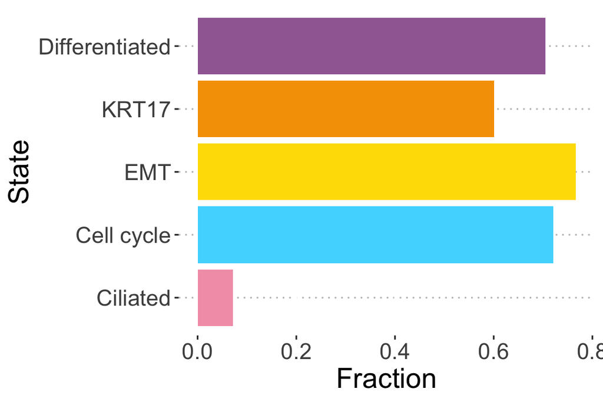

```r
plot.data2 <- data.frame(State = c("Differentiated","KRT17","EMT","Cell cycle","Ciliated"),
                         Fraction = colSums(svr_fit_new[,1:5] > 0)/nrow(svr_fit_new))
plot.data2$State <- factor(plot.data2$State, levels = c("Differentiated","KRT17","EMT","Cell cycle","Ciliated")[5:1])
ggplot(plot.data2) + geom_bar(aes(y = Fraction,  x = State , fill = State),stat = "identity")+ theme_pubclean() + coord_flip()+
  scale_fill_manual(values = c("#A16BA3","#F6A000","#FFDE00","#4DD9FF","#F3A1B6")[5:1],
                    breaks = c("Differentiated","KRT17","EMT","Cell cycle","Ciliated"),
                    labels = c("Differentiated","KRT17","EMT","Cell cycle","Ciliated")) +
  theme(legend.position = "none", axis.text = element_text(size = 16), axis.title = element_text(size = 20))
```

```r
# ggsave("plots/Fig4_TCGA_barplot_20190509.png", width = 4, height = 5)
```

### 7.1.2 t-SNE plot

```r
colnames(svr_fit_new)[c(1,2,4,5)] <- c("Differentiated","KRT17","Cell_cycle","Ciliated")

set.seed(158163)
tsne_res <- tsne::tsne(svr_fit_new[,1:5], k = 2, perplexity = round(0.05*nrow(svr_fit_new)))
```

```
## sigma summary: Min. : 0.281056109333764 |1st Qu. : 0.403305279240257 |Median : 0.433245759089702 |Mean : 0.44410475855357 |3rd Qu. : 0.458201925105878 |Max. : 1.097579595917 |
```

```
## Epoch: Iteration #100 error is: 13.3008527976745
```

```
## Epoch: Iteration #200 error is: 0.423552713863325
```

```
## Epoch: Iteration #300 error is: 0.398316698481331
```

```
## Epoch: Iteration #400 error is: 0.35846144404985
```

```
## Epoch: Iteration #500 error is: 0.354977653103932
```

```
## Epoch: Iteration #600 error is: 0.353930954008961
```

```
## Epoch: Iteration #700 error is: 0.3532442020859
```

```
## Epoch: Iteration #800 error is: 0.352750571372677
```

```
## Epoch: Iteration #900 error is: 0.352355105791957
```

```
## Epoch: Iteration #1000 error is: 0.351992992090113
```

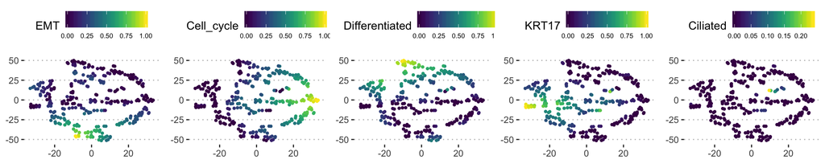

```r
df_tsne <- data.frame(TSNE_1 = tsne_res[,1],
                     TSNE_2 = tsne_res[,2],
                     EMT = svr_fit_new[,"EMT"],
                     Cell_cycle = svr_fit_new[,"Cell_cycle"],
                     Differentiated = svr_fit_new[,1],
                     KRT17 = svr_fit_new[,2],
                     Ciliated =  svr_fit_new[,5],
                     sample = rownames(svr_fit_new))
p1 <- ggplot(df_tsne, aes(x = TSNE_1, y = TSNE_2, col = EMT)) + geom_point(size = 1) + theme_pubclean() + scale_color_viridis() + theme(axis.title = element_blank() , legend.text = element_text(size = 7))
p2 <- ggplot(df_tsne, aes(x = TSNE_1, y = TSNE_2, col = Cell_cycle)) + geom_point(size =1) + theme_pubclean() + scale_color_viridis() + theme(axis.title = element_blank() , legend.text = element_text(size = 7))
p3 <- ggplot(df_tsne, aes(x = TSNE_1, y = TSNE_2, col = Differentiated)) + geom_point(size = 1) + theme_pubclean() + scale_color_viridis() + theme(axis.title = element_blank() , legend.text = element_text(size = 7))
p4 <- ggplot(df_tsne, aes(x = TSNE_1, y = TSNE_2, col = KRT17)) + geom_point(size = 1) + theme_pubclean() + scale_color_viridis() + theme(axis.title = element_blank() , legend.text = element_text(size = 7))
p5 <- ggplot(df_tsne, aes(x = TSNE_1, y = TSNE_2, col = Ciliated)) + geom_point(size = 1) + theme_pubclean() + scale_color_viridis() + theme(axis.title = element_blank() , legend.text = element_text(size = 7))
cowplot::plot_grid(p1,p2,p3,p4,p5, ncol = 5)
```

```r
# ggsave("plots/Fig6_TSNE_deconvolution_TCGA.pdf",device = "pdf", width = 12.5, height = 3)
```

### 7.1.3 Survival analysis

Univariate survival anlaysis gave significant p-value and hazard ratio ~ 2.3

```r
# eset$emt_new <- scale(svr_fit_new[,"EMT"], scale = T, center = T)
eset$emt_new <- svr_fit_new[,"EMT"]
fit <- coxph(Surv(OS.time, OS)~emt_new, data=pData(eset))
summary(fit)
```

```
## Call:
## coxph(formula = Surv(OS.time, OS) ~ emt_new, data = pData(eset))
##
##   n= 307, number of events= 184
##    (1 observation deleted due to missingness)
##
##           coef exp(coef) se(coef)     z Pr(>|z|)
## emt_new 0.8316    2.2971   0.2940 2.829  0.00467 **
## ---
## Signif. codes:  0 '***' 0.001 '**' 0.01 '*' 0.05 '.' 0.1 ' ' 1
##
##         exp(coef) exp(-coef) lower .95 upper .95
## emt_new     2.297     0.4353     1.291     4.087
##
## Concordance= 0.572  (se = 0.022 )
## Rsquare= 0.024   (max possible= 0.997 )
## Likelihood ratio test= 7.44  on 1 df,   p=0.006
## Wald test            = 8  on 1 df,   p=0.005
## Score (logrank) test = 8.08  on 1 df,   p=0.004
```

Multivariate analysis

```r
fit <- coxph(Surv(OS.time, OS)~emt_new+stage_dichotomized, data=pData(eset))
summary(fit)
```

```
## Call:
## coxph(formula = Surv(OS.time, OS) ~ emt_new + stage_dichotomized,
##     data = pData(eset))
##
##   n= 307, number of events= 184
##    (1 observation deleted due to missingness)
##
##                          coef exp(coef) se(coef)     z Pr(>|z|)
## emt_new                0.7785    2.1783   0.2972 2.620   0.0088 **
## stage_dichotomizedlate 0.4090    1.5054   0.3657 1.118   0.2634
## ---
## Signif. codes:  0 '***' 0.001 '**' 0.01 '*' 0.05 '.' 0.1 ' ' 1
##
##                        exp(coef) exp(-coef) lower .95 upper .95
## emt_new                    2.178     0.4591    1.2167     3.900
## stage_dichotomizedlate     1.505     0.6643    0.7351     3.083
##
## Concordance= 0.577  (se = 0.022 )
## Rsquare= 0.028   (max possible= 0.997 )
## Likelihood ratio test= 8.85  on 2 df,   p=0.01
## Wald test            = 9.05  on 2 df,   p=0.01
## Score (logrank) test = 9.2  on 2 df,   p=0.01
```

## 7.2 Cibersort AOCS

```r
svr_fit_tot <- cibersort_my(sig_matrix = sig_matrix_new, exprs_unlogged = exprs_tot)
toteset$emt.new <- svr_fit_tot[,"EMT"]
# saveRDS(svr_fit_tot, "results/20190502Deconvolution_Tothill.rds", compress = T)
# only for high-grade and late stage patients
fit_tot <- coxph(Surv(time.to.death, OS)~emt.new, data=pData(toteset)[toteset$histological.subtype2 == "ser" ,])
summary(fit_tot)
```

```
## Call:
## coxph(formula = Surv(time.to.death, OS) ~ emt.new, data = pData(toteset)[toteset$histological.subtype2 ==
##     "ser", ])
##
##   n= 257, number of events= 110
##    (7 observations deleted due to missingness)
##
##           coef exp(coef) se(coef)     z Pr(>|z|)
## emt.new 0.9290    2.5319   0.2793 3.326 0.000882 ***
## ---
## Signif. codes:  0 '***' 0.001 '**' 0.01 '*' 0.05 '.' 0.1 ' ' 1
##
##         exp(coef) exp(-coef) lower .95 upper .95
## emt.new     2.532      0.395     1.464     4.377
##
## Concordance= 0.609  (se = 0.031 )
## Rsquare= 0.04   (max possible= 0.981 )
## Likelihood ratio test= 10.44  on 1 df,   p=0.001
## Wald test            = 11.06  on 1 df,   p=9e-04
## Score (logrank) test = 11.36  on 1 df,   p=8e-04
```

The univariate survival analysis on AOCS data (serous OvCa only) showed HR = 2.53 with p = 0.000882.

Multivariate analysis

```r
fit_tot <- coxph(Surv(time.to.death, OS)~emt.new+summarystage+summarygrade, data=pData(toteset)[toteset$histological.subtype2 == "ser" ,])
summary(fit_tot)
```

```
## Call:
## coxph(formula = Surv(time.to.death, OS) ~ emt.new + summarystage +
##     summarygrade, data = pData(toteset)[toteset$histological.subtype2 ==
##     "ser", ])
##
##   n= 253, number of events= 109
##    (11 observations deleted due to missingness)
##
##                     coef exp(coef) se(coef)      z Pr(>|z|)
## emt.new           0.7533    2.1240   0.2819  2.672  0.00754 **
## summarystagelate  1.3790    3.9709   0.6110  2.257  0.02400 *
## summarygradelow  -0.3618    0.6965   0.6095 -0.593  0.55285
## ---
## Signif. codes:  0 '***' 0.001 '**' 0.01 '*' 0.05 '.' 0.1 ' ' 1
##
##                  exp(coef) exp(-coef) lower .95 upper .95
## emt.new             2.1240     0.4708    1.2223     3.691
## summarystagelate    3.9709     0.2518    1.1990    13.151
## summarygradelow     0.6965     1.4358    0.2109     2.300
##
## Concordance= 0.639  (se = 0.03 )
## Rsquare= 0.081   (max possible= 0.981 )
## Likelihood ratio test= 21.39  on 3 df,   p=9e-05
## Wald test            = 15.83  on 3 df,   p=0.001
## Score (logrank) test = 18.36  on 3 df,   p=4e-04
```

### 7.2.1 Barplots

```r
svr_fit_new_diff <- svr_fit_tot[svr_fit_tot[,1] > 0.5,]
svr_fit_new_diff <- svr_fit_new_diff[order(svr_fit_new_diff[,1], decreasing = F),]
svr_fit_new_krt <- svr_fit_tot[svr_fit_tot[,2] > 0.5,]
svr_fit_new_krt <- svr_fit_new_krt[order(svr_fit_new_krt[,2], decreasing = F),]
svr_fit_new_emt <- svr_fit_tot[svr_fit_tot[,3] > 0.5,]
svr_fit_new_emt <- svr_fit_new_emt[order(svr_fit_new_emt[,3], decreasing = F),]
svr_fit_new_cc <- svr_fit_tot[svr_fit_tot[,4] > 0.5,]
svr_fit_new_cc <- svr_fit_new_cc[order(svr_fit_new_cc[,4], decreasing = F),]
svr_fit_new_cil <- svr_fit_tot[svr_fit_tot[,5] > 0.5,]
svr_fit_new_cil <- svr_fit_new_cil[order(svr_fit_new_cil[,5], decreasing = F),]
svr_fit_new_others <- svr_fit_tot[!rownames(svr_fit_tot) %in% c(rownames(svr_fit_new_diff),rownames(svr_fit_new_krt),
                                                               rownames(svr_fit_new_emt),rownames(svr_fit_new_cc),
                                                               rownames(svr_fit_new_cil)),]

plot.data <- data.frame(sample = rep(rownames(svr_fit_tot), 5),
                        state = rep(c("Differentiated","KRT17","EMT","Cell cycle","Ciliated"), each = nrow(svr_fit_tot)),
                        score = c(svr_fit_tot[,1],
                                  svr_fit_tot[,2],
                                  svr_fit_tot[,3],
                                  svr_fit_tot[,4],
                                  svr_fit_tot[,5]))
plot.data$sample <- factor(plot.data$sample, levels = c(rownames(svr_fit_new_diff),rownames(svr_fit_new_krt),
                                                               rownames(svr_fit_new_emt),rownames(svr_fit_new_cc),
                                                        rownames(svr_fit_new_cil),
                                                        rownames(svr_fit_new_others)))
plot.data$state <- factor(plot.data$state, levels = c("Differentiated","KRT17","EMT","Cell cycle","Ciliated"))
# differentiated #A16BA3
# F6A000 KRT7
# FFDE00 EMT
# CC #4DD9FF
#F3A1B6 Ciliated
```

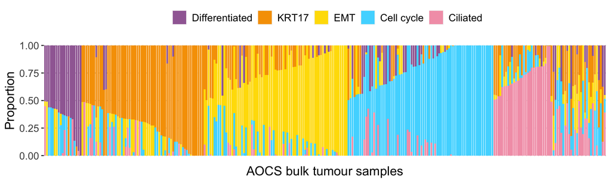

```r
ggplot(plot.data) + geom_bar(aes(y = score, x = sample, fill = state),
                           stat="identity") + theme_pubclean() +
  scale_fill_manual(values = c("#A16BA3","#F6A000","#FFDE00","#4DD9FF","#F3A1B6"),
                    breaks = c("Differentiated","KRT17","EMT","Cell cycle","Ciliated"),
                    labels = c("Differentiated","KRT17","EMT","Cell cycle","Ciliated")) +
  xlab("AOCS bulk tumour samples") + ylab("Proportion") +
  theme(axis.ticks.x  = element_blank(), axis.text.x = element_blank(),
        axis.text.y = element_text(size = 12),
        axis.title = element_text(size= 15),
        legend.text = element_text(size = 12),
        legend.title  = element_blank())
```

```r
# ggsave("plots/Fig4_AOCS_stackedBarplot_20190509.png", width = 10, height = 5)
```

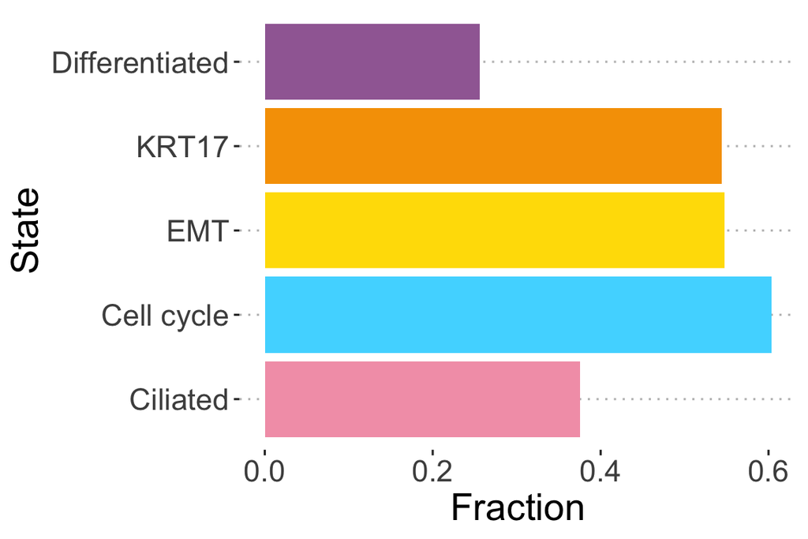

```r
plot.data2 <- data.frame(State = c("Differentiated","KRT17","EMT","Cell cycle","Ciliated"),
                         Fraction = colSums(svr_fit_tot[,1:5] > 0)/nrow(svr_fit_tot))
plot.data2$State <- factor(plot.data2$State, levels = c("Differentiated","KRT17","EMT","Cell cycle","Ciliated")[5:1])
ggplot(plot.data2) + geom_bar(aes(y = Fraction,  x = State , fill = State),stat = "identity")+ theme_pubclean() + coord_flip()+
  scale_fill_manual(values = c("#A16BA3","#F6A000","#FFDE00","#4DD9FF","#F3A1B6")[5:1],
                    breaks = c("Differentiated","KRT17","EMT","Cell cycle","Ciliated"),
                    labels = c("Differentiated","KRT17","EMT","Cell cycle","Ciliated")) +
  theme(legend.position = "none", axis.text = element_text(size = 16), axis.title = element_text(size = 20))
```

```r
# ggsave("plots/Fig4_AOCS_barplot_20190509.png", width = 4, height = 5)
```

### 7.2.2 Heatmap: TCGA & AOCS

We plot the heatmap for the diagram

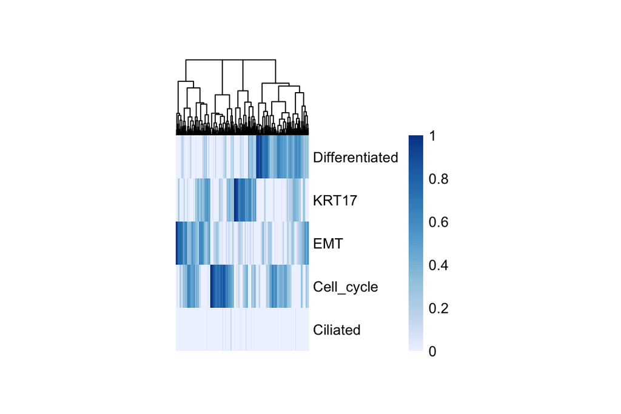

```r
data.heatmap <- t(svr_fit_new[,1:5])
pheatmap::pheatmap(data.heatmap, color = colorRampPalette(brewer.pal(n = 7, name = "Blues"))(100),
  show_colnames = F, show_rownames = T, cluster_rows = F, cellheight = 30, cellwidth = 0.3)
```

```r
# pdf("plots/Fig4_heatmap_mini_tcga_20190510.pdf", height = 5, width = 5)
# pheatmap::pheatmap(data.heatmap, color = colorRampPalette(brewer.pal(n = 7, name = "Blues"))(100),
#   show_colnames = F, show_rownames = T, cluster_rows = F, cellheight = 30, cellwidth = 0.3)
# dev.off()
```

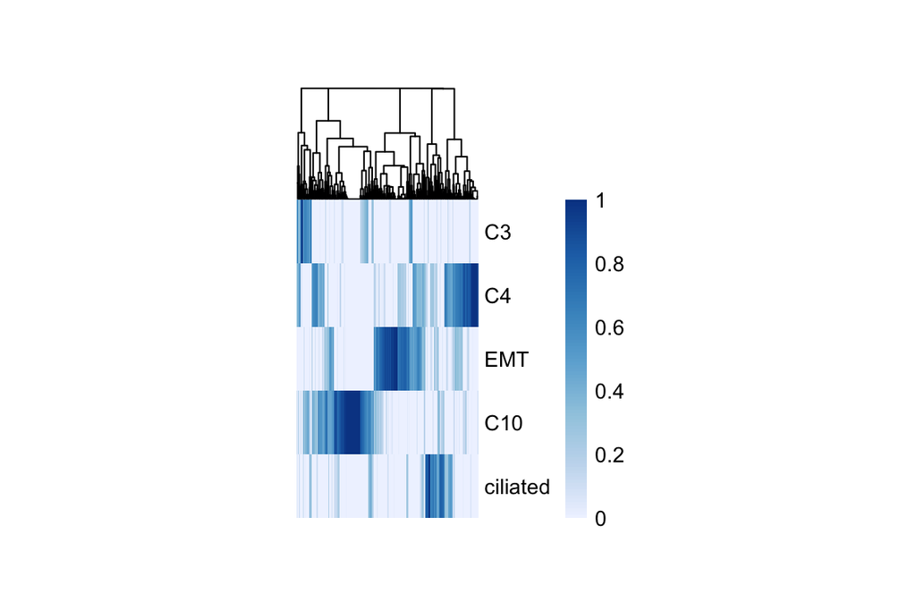

```r
data.heatmap <- t(svr_fit_tot[,1:5])
pheatmap::pheatmap(data.heatmap, color = colorRampPalette(brewer.pal(n = 7, name = "Blues"))(100),
  show_colnames = F, show_rownames = T, cluster_rows = F, cellheight = 30, cellwidth = 0.3)
```

```r
# pdf("plots/Fig4_heatmap_mini_aocs_20190510.pdf", height = 5, width = 5)
# pheatmap::pheatmap(data.heatmap, color = colorRampPalette(brewer.pal(n = 7, name = "Blues"))(100),
#   show_colnames = F, show_rownames = T, cluster_rows = F, cellheight = 30, cellwidth = 0.3)
# dev.off()
```

## 7.3 Cibersort OXO-PCR

```r
svr_fit_oxo <- cibersort_my(sig_matrix = sig_matrix_new, exprs_unlogged = cpm(as.matrix(oxopcr_pre)))
```

### 7.3.1 Heatmap

```r
rownames(svr_fit_oxo) <- gsub(rownames(svr_fit_oxo), pattern = "X", replacement = "")
colnames(svr_fit_oxo)[1:5] <- c("Differentiated", "KRT17","EMT","Cell cycle","Ciliated")
rownames(svr_fit_oxo)[rownames(svr_fit_oxo) == "1G3_new"] <- "1016_1G3new"
```

### 7.3.2 Stacked barplot

```r
svr_fit_new_diff <- svr_fit_oxo[svr_fit_oxo[,1] > 0.5,]
svr_fit_new_diff <- svr_fit_new_diff[order(svr_fit_new_diff[,1], decreasing = F),]
svr_fit_new_krt <- svr_fit_oxo[svr_fit_oxo[,2] > 0.5,]
svr_fit_new_krt <- svr_fit_new_krt[order(svr_fit_new_krt[,2], decreasing = F),]
svr_fit_new_emt <- svr_fit_oxo[svr_fit_oxo[,3] > 0.5,]
svr_fit_new_emt <- svr_fit_new_emt[order(svr_fit_new_emt[,3], decreasing = F),]
svr_fit_new_cc <- svr_fit_oxo[svr_fit_oxo[,4] > 0.5,]
svr_fit_new_cc <- svr_fit_new_cc[order(svr_fit_new_cc[,4], decreasing = F),]
svr_fit_new_others <- svr_fit_oxo[!rownames(svr_fit_oxo) %in% c(rownames(svr_fit_new_diff),rownames(svr_fit_new_krt),
                                                               rownames(svr_fit_new_emt),rownames(svr_fit_new_cc)),]

plot.data <- data.frame(sample = rep(rownames(svr_fit_oxo), 5),
                        state = rep(c("Differentiated","KRT17","EMT","Cell cycle","Ciliated"),
                                    each = nrow(svr_fit_oxo)),
                        score = c(svr_fit_oxo[,1],
                                  svr_fit_oxo[,2],
                                  svr_fit_oxo[,3],
                                  svr_fit_oxo[,4],
                                  svr_fit_oxo[,5]))
plot.data$sample <- factor(plot.data$sample, levels = c(rownames(svr_fit_new_diff),rownames(svr_fit_new_krt),
                                                               rownames(svr_fit_new_emt),rownames(svr_fit_new_cc),
                                                        rownames(svr_fit_new_others)))
plot.data$state <- factor(plot.data$state, levels = c("Differentiated","KRT17","EMT","Cell cycle","Ciliated"))
# differentiated #A16BA3
# F6A000 KRT7
# FFDE00 EMT
# CC #4DD9FF
#F3A1B6 Ciliated
```

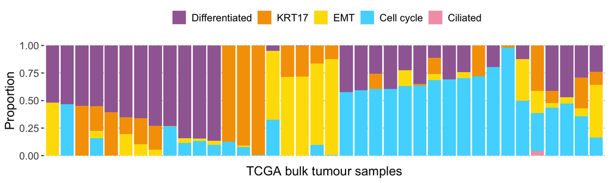

```r
ggplot(plot.data) + geom_bar(aes(y = score, x = sample, fill = state),
                           stat="identity") + theme_pubclean() +
  scale_fill_manual(values = c("#A16BA3","#F6A000","#FFDE00","#4DD9FF","#F3A1B6"),
                    breaks = c("Differentiated","KRT17","EMT","Cell cycle","Ciliated"),
                    labels = c("Differentiated","KRT17","EMT","Cell cycle","Ciliated")) +
  xlab("TCGA bulk tumour samples") + ylab("Proportion") +
  theme(axis.ticks.x  = element_blank(), axis.text.x = element_blank(),
        axis.text.y = element_text(size = 12),
        axis.title = element_text(size= 15),
        legend.text = element_text(size = 12),
        legend.title  = element_blank())
```

```r
# ggsave("plots/Fig5_OXOPCR_stackedBarplot_20190509.png", width = 7, height = 3)
```

## 7.4 Permutation test

In the permutation test, we select 90 percent of the samples from each dataset and reran the survival analysis to make sure that the association between EMT scores and the overall survival is robust (not affected by few extreme cases).

For TCGA data

```r
Perm <- 500
prob <- 0.9

p_val_tcga <- c()

for(itor in 1:Perm){
  idx <- sample(x = 1:ncol(eset), size = round(ncol(eset) * prob), replace = F)
  fit <- coxph(Surv(OS.time, OS)~emt_new, data=pData(eset)[idx,])
  p_val_tcga <- c(p_val_tcga, summary(fit)$coef[,5])
}

sum(p_val_tcga <= 0.05)/500 * 100
```

```
## [1] 99.4
```

For the high-grade tumours in Tothill’s data

```r
Perm <- 500
prob <- 0.9 # select 90% samples each time

p_val_tot <- c()

for(itor in 1:Perm){
  idx <- sample(x = which(toteset$Grade >= 2 & toteset$histological.subtype2 == "ser"), size = round(sum(toteset$Grade >= 2 & toteset$histological.subtype2 == "ser", na.rm = TRUE) * prob), replace = F)
  fit <- coxph(Surv(time.to.death, OS)~emt.new, data=pData(toteset)[idx,])
  p_val_tot <- c(p_val_tot, summary(fit)$coef[,5])
}

sum(p_val_tot <= 0.05)/500 * 100
```

```
## [1] 99.8
```

## 7.5 CuratedOvarianCancer database

```r
## read in the list of selected CuratedOvarianCancer database
esets <- readRDS("../../scFT-paper_rds/20190213CuratedOvarianData_esets.rds")

svr_fit <- list() # record cibersort results
fit <- list() # survival analysis results
esets_tumor <- list()

# go through all the datasets, run cibersort
for(itor in 1:length(esets)) {

  ## tumor data/remove the benign or borderline samples
  eset_tmp <- esets[[itor]][,esets[[itor]]$sample_type %in% c("tumor","metastatic")]

  ## deconvolution
  if(max(na.omit(eset_tmp@assayData$exprs)) < 50) { ## if log-space, unlog it
    svr_fit[[itor]] <- cibersort_my(sig_matrix = sig_matrix_new,
                                    exprs_unlogged = exp(na.omit(eset_tmp@assayData$exprs)))
  } else {         # non-log space
    svr_fit[[itor]] <- cibersort_my(sig_matrix = sig_matrix_new,
                                    exprs_unlogged = eset_tmp@assayData$exprs)
  }
}
```

### 7.5.1 Manually iterations

We applied survival analysis on the serous ovarian cancer cases with stage and grade as covariate.

```r
itor=1
eset_tmp <- esets[[itor]][,esets[[itor]]$sample_type %in% c("tumor","metastatic")]
# # survival data
eset_tmp$y <- Surv(eset_tmp$days_to_death,
                     eset_tmp$vital_status == "deceased")
eset_tmp$emt <- svr_fit[[itor]][,"EMT"]

table(eset_tmp$sample_type)
```

```
##
## tumor
##   129
```

```r
table(eset_tmp$histological_type)
```

```
##
## ser
## 129
```

```r
table(eset_tmp$summarygrade)
```

```
##
## high
##  129
```

```r
table(eset_tmp$summarystage)
```

```
##
## early  late
##     1   128
```

```r
eset_tmp <- eset_tmp[,eset_tmp$summarystage == "late"]
fit[[itor]] <- coxph(y~emt, eset_tmp)
esets_tumor[[itor]] <- eset_tmp

#####

itor=2
eset_tmp <- esets[[itor]][,esets[[itor]]$sample_type %in% c("tumor","metastatic")]
# # survival data
eset_tmp$y <- Surv(eset_tmp$days_to_death,
                     eset_tmp$vital_status == "deceased")
eset_tmp$emt <- svr_fit[[itor]][,"EMT"]

table(eset_tmp$sample_type)
```

```
##
## tumor
##   157
```

```r
table(eset_tmp$histological_type)
```

```
##
## ser
## 157
```

```r
table(eset_tmp$summarygrade)
```

```
##
## high  low
##   85   59
```

```r
table(eset_tmp$summarystage)
```

```
##
## late
##  157
```

```r
fit[[itor]] <- coxph(y~emt+summarygrade, eset_tmp)
esets_tumor[[itor]] <- eset_tmp

#####

itor=3
eset_tmp <- esets[[itor]][,esets[[itor]]$sample_type %in% c("tumor","metastatic")]
# # survival data
eset_tmp$y <- Surv(eset_tmp$days_to_death,
                     eset_tmp$vital_status == "deceased")
eset_tmp$emt <- svr_fit[[itor]][,"EMT"]

table(eset_tmp$sample_type)
```

```
##
## tumor
##   107
```

```r
table(eset_tmp$histological_type)
```

```
##
## clearcell      endo  mucinous     other       ser
##         6         8         8         6        79
```

```r
eset_tmp <- eset_tmp[,eset_tmp$histological_type=="ser"]
table(eset_tmp$summarygrade)
```

```
##
## high  low
##   56   23
```

```r
table(eset_tmp$summarystage)
```

```
##
## early  late
##    17    62
```

```r
# early  late
#    17    62


fit[[itor]] <- coxph(y~emt+summarygrade+summarystage, eset_tmp)
esets_tumor[[itor]] <- eset_tmp


#####

itor=4
eset_tmp <- esets[[itor]][,esets[[itor]]$sample_type %in% c("tumor","metastatic")]
# # survival data
eset_tmp$y <- Surv(eset_tmp$days_to_death,
                     eset_tmp$vital_status == "deceased")
eset_tmp$emt <- svr_fit[[itor]][,"EMT"]

table(eset_tmp$sample_type)
```

```
##
## tumor
##   185
```

```r
table(eset_tmp$histological_type)
```

```
##
## ser
## 185
```

```r
# eset_tmp <- eset_tmp[,eset_tmp$histological_type=="ser"]
table(eset_tmp$summarygrade)
```

```
##
## high
##  185
```

```r
table(eset_tmp$summarystage)
```

```
##
## late
##  185
```

```r
# late
#  185
fit[[itor]] <- coxph(y~emt, eset_tmp)
esets_tumor[[itor]] <- eset_tmp

#####

itor=5
eset_tmp <- esets[[itor]][,esets[[itor]]$sample_type %in% c("tumor","metastatic")]
# # survival data
eset_tmp$y <- Surv(eset_tmp$days_to_death,
                     eset_tmp$vital_status == "deceased")
eset_tmp$emt <- svr_fit[[itor]][,"EMT"]

table(eset_tmp$sample_type)
```

```
##
## tumor
##   260
```

```r
table(eset_tmp$histological_type)
```

```
##
## ser
## 260
```

```r
# eset_tmp <- eset_tmp[,eset_tmp$histological_type=="ser"]
table(eset_tmp$summarygrade)
```

```
##
## high  low
##  129  131
```

```r
table(eset_tmp$summarystage)
```

```
##
## late
##  260
```

```r
# late
#  260


fit[[itor]] <- coxph(y~emt+summarygrade, eset_tmp)
esets_tumor[[itor]] <- eset_tmp

#####

itor=6
eset_tmp <- esets[[itor]][,esets[[itor]]$sample_type %in% c("tumor","metastatic")]
# # survival data
eset_tmp$y <- Surv(eset_tmp$days_to_death,
                     eset_tmp$vital_status == "deceased")
eset_tmp$emt <- svr_fit[[itor]][,"EMT"]

table(eset_tmp$sample_type)
```

```
##
## tumor
##   204
```

```r
table(eset_tmp$histological_type)
```

```
##
## other   ser
##    23   171
```

```r
eset_tmp <- eset_tmp[,eset_tmp$histological_type=="ser"]
table(eset_tmp$summarygrade)
```

```
##
## high  low
##  125   45
```

```r
table(eset_tmp$summarystage)
```

```
##
## early  late
##     5   166
```

```r
# early  late
#     5   166
fit[[itor]] <- coxph(y~emt+summarygrade+ summarystage, eset_tmp)
esets_tumor[[itor]] <- eset_tmp

#####

itor=7
eset_tmp <- esets[[itor]][,esets[[itor]]$sample_type %in% c("tumor","metastatic")]
# # survival data
eset_tmp$y <- Surv(eset_tmp$days_to_death,
                     eset_tmp$vital_status == "deceased")
eset_tmp$emt <- svr_fit[[itor]][,"EMT"]

eset_tmp <- eset_tmp[,!is.na(eset_tmp$days_to_death)]

table(eset_tmp$sample_type)
```

```
##
## metastatic      tumor
##         17        122
```

```r
table(eset_tmp$histological_type)
```

```
##
## clearcell      endo  mucinous     other       ser
##         3         7         5        11       113
```

```r
eset_tmp <- eset_tmp[,eset_tmp$histological_type=="ser"]
table(eset_tmp$summarygrade)
```

```
##
## high  low
##  100   13
```

```r
table(eset_tmp$summarystage)
```

```
##
## early  late
##     5   108
```

```r
# early  late
#     5   108
fit[[itor]] <- coxph(y~emt+summarygrade+summarystage, eset_tmp)
esets_tumor[[itor]] <- eset_tmp
```

### 7.5.2 Generate table 1

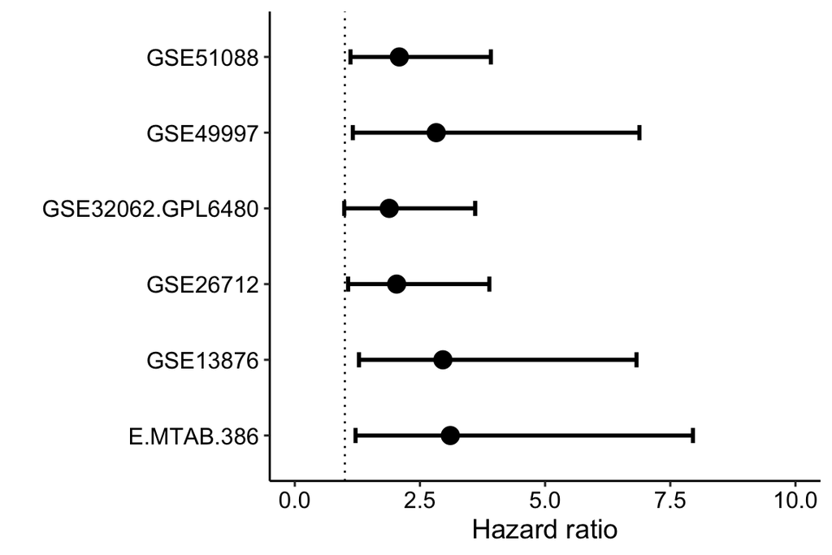

```r
df <- matrix(NA, nrow = 7, ncol = 6)
colnames(df) <- c("nsamples","nevent","hazard_ratio","pvalue","lower.CI95","upper.CI95")
df <- as.data.frame(df)
for(itor in 1:7){
  df$lower.CI95[itor] <- summary(fit[[itor]])$conf.int[1,3]
  df$upper.CI95[itor] <- summary(fit[[itor]])$conf.int[1,4]
  df$hazard_ratio[itor] <- summary(fit[[itor]])$conf.int[1,1]
  df$pvalue[itor] <- summary(fit[[itor]])$coefficient[1,5]
  df$nsamples[itor] <- summary(fit[[itor]])$n
  df$nevent[itor] <- summary(fit[[itor]])$nevent
}

df$database <- c("E.MTAB.386", "GSE13876", "GSE26193",
              "GSE26712", "GSE32062.GPL6480",
              "GSE49997", "GSE51088")

# write.csv(df, "../revision_tables/20191009CuratedOvarianData_results_multivariable_test.csv", row.names = F)

## IC95 error bar plot----
df <- df[order(df$hazard_ratio, decreasing = T),]
df <- df[!grepl("TCGA",df$database),]
ggplot(df[which(df$nsamples > 100),], aes(y = database, x = hazard_ratio))+ geom_point(shape=21, fill = "black",size=4) +
  geom_errorbarh(aes(xmax = upper.CI95, xmin = lower.CI95), height=0.2, size=1) + theme_survminer() +xlim(c(0, 10)) +
  geom_vline(xintercept = 1, lty = 3, col = "black") + xlab("Hazard ratio") +ylab("")
```

```r
# ggsave("plots_explore/20190213Hazard_ratio_CI95_CuratedOvarianData.png",width = 5, height = 6)
```

```r
knitr::kable(df)
```

|  | nsamples | nevent | hazard_ratio | pvalue | lower.CI95 | upper.CI95 | database |
| --- | --- | --- | --- | --- | --- | --- | --- |
| 1 | 128 | 73 | 3.106670 | 0.0180938 | 1.2136294 | 7.952507 | E.MTAB.386 |
| 2 | 144 | 105 | 2.958312 | 0.0110061 | 1.2821128 | 6.825927 | GSE13876 |
| 6 | 170 | 47 | 2.825166 | 0.0222851 | 1.1594183 | 6.884108 | GSE49997 |
| 3 | 79 | 60 | 2.581707 | 0.0413288 | 1.0380122 | 6.421132 | GSE26193 |
| 7 | 113 | 93 | 2.087432 | 0.0218881 | 1.1125965 | 3.916399 | GSE51088 |
| 4 | 185 | 129 | 2.034529 | 0.0314708 | 1.0651342 | 3.886183 | GSE26712 |
| 5 | 260 | 121 | 1.886066 | 0.0547279 | 0.9872229 | 3.603286 | GSE32062.GPL6480 |

# 8 Put all datasets together

```r
## put all datasets together
esets_tumor[[6]] <- esets_tumor[[6]][,!is.na(esets_tumor[[6]]$alt_sample_name)]
df_all <- data.frame(database = c(rep("E.MTAB.386",ncol(esets_tumor[[1]])),
                                  rep("GSE13876",ncol(esets_tumor[[2]])),
                                  rep("GSE26193",ncol(esets_tumor[[3]])),
                                  rep("GSE26712",ncol(esets_tumor[[4]])),
                                  rep("GSE32062.GPL6480",ncol(esets_tumor[[5]])),
                                  rep("GSE49997",ncol(esets_tumor[[6]])),
                                  rep("GSE51088",ncol(esets_tumor[[7]])),
                                  rep("AOCS", ncol(toteset)),
                                  rep("TCGA", ncol(eset))),

                     sample_type = c(esets_tumor[[1]]$sample_type,esets_tumor[[2]]$sample_type,
                                     esets_tumor[[3]]$sample_type,esets_tumor[[4]]$sample_type,
                                     esets_tumor[[5]]$sample_type,esets_tumor[[6]]$sample_type,
                                     esets_tumor[[7]]$sample_type, rep("tumor",ncol(toteset)),
                                     rep("tumor", ncol(eset))),

                     grade = c(esets_tumor[[1]]$summarygrade,esets_tumor[[2]]$summarygrade,
                               esets_tumor[[3]]$summarygrade,esets_tumor[[4]]$summarygrade,
                              esets_tumor[[5]]$summarygrade,
                               esets_tumor[[6]]$summarygrade,esets_tumor[[7]]$summarygrade,
                               toteset$summarygrade,
                               rep("high", ncol(eset))),
                     stage = c(esets_tumor[[1]]$summarystage,esets_tumor[[2]]$summarystage,
                               esets_tumor[[3]]$summarystage,esets_tumor[[4]]$summarystage,
                              esets_tumor[[5]]$summarystage,
                               esets_tumor[[6]]$summarystage,esets_tumor[[7]]$summarystage,
                               toteset$summarystage,
                               eset$stage_dichotomized),
                     histological_type = c(esets_tumor[[1]]$histological_type,esets_tumor[[2]]$histological_type,
                                           esets_tumor[[3]]$histological_type,esets_tumor[[4]]$histological_type,
                                        esets_tumor[[5]]$histological_type,esets_tumor[[6]]$histological_type,
                                        esets_tumor[[7]]$histological_type, tolower(toteset$histological.subtype),
                                        rep("ser", ncol(eset)))
                     )

toteset$vital_status <- NA
toteset$vital_status[toteset$patient.status != "D"] <- "living"
toteset$vital_status[toteset$patient.status == "D"] <- "deceased"

df_all$OS <- c(esets_tumor[[1]]$vital_status,esets_tumor[[2]]$vital_status,
               esets_tumor[[3]]$vital_status,esets_tumor[[4]]$vital_status,
               esets_tumor[[5]]$vital_status,esets_tumor[[6]]$vital_status,
               esets_tumor[[7]]$vital_status,toteset$vital_status, tolower(eset$vital_status)
               )

df_all$days_to_death <- c(esets_tumor[[1]]$days_to_death,esets_tumor[[2]]$days_to_death,
                          esets_tumor[[3]]$days_to_death,esets_tumor[[4]]$days_to_death,
                          esets_tumor[[5]]$days_to_death,esets_tumor[[6]]$days_to_death,
                          esets_tumor[[7]]$days_to_death,
                          toteset$time.to.death*30,
                          eset$OS.time)

# df_all <- df_all[df_all$sample_type %in% c("metastatic","tumor"),]

df_all$EMT <- c( esets_tumor[[1]]$emt, esets_tumor[[2]]$emt,
                  esets_tumor[[3]]$emt,  esets_tumor[[4]]$emt,
                  esets_tumor[[5]]$emt, esets_tumor[[6]]$emt,
                  esets_tumor[[7]]$emt,
                 toteset$emt.new, eset$EMT)


# saveRDS(fit,"results/20181122CuratedOvarianData_survival_list.rds",compress = T)
df_all$years_to_death <- df_all$days_to_death/365
df_all$y <- Surv(df_all$years_to_death,
                     df_all$OS == "deceased")

df_all <- df_all[which(df_all$histological_type == "ser"),]

# survival analysis on the merged data
fit <- coxph(y~EMT+grade+stage, data = df_all)
summary(fit)
```

```
## Call:
## coxph(formula = y ~ EMT + grade + stage, data = df_all)
##
##   n= 1639, number of events= 921
##    (26 observations deleted due to missingness)
##
##               coef exp(coef) se(coef)      z Pr(>|z|)
## EMT        0.78004   2.18156  0.10819  7.210 5.61e-13 ***
## gradelow  -0.28234   0.75402  0.09249 -3.053  0.00227 **
## stagelate  0.62038   1.85963  0.20462  3.032  0.00243 **
## ---
## Signif. codes:  0 '***' 0.001 '**' 0.01 '*' 0.05 '.' 0.1 ' ' 1
##
##           exp(coef) exp(-coef) lower .95 upper .95
## EMT           2.182     0.4584     1.765    2.6969
## gradelow      0.754     1.3262     0.629    0.9039
## stagelate     1.860     0.5377     1.245    2.7772
##
## Concordance= 0.597  (se = 0.01 )
## Rsquare= 0.045   (max possible= 0.999 )
## Likelihood ratio test= 76.09  on 3 df,   p=<2e-16
## Wald test            = 73.75  on 3 df,   p=7e-16
## Score (logrank) test = 75.53  on 3 df,   p=3e-16
```

## 8.1 Overall KM plot

```r
df_all$EMT_group <- NA

for(itor in 1:9){
   emt_tmp <- median(df_all$EMT[df_all$database == unique(df_all$database)[itor]])
   df_all$EMT_group[df_all$database == unique(df_all$database)[itor] & df_all$EMT > emt_tmp] <- "high"
   df_all$EMT_group[df_all$database == unique(df_all$database)[itor] & df_all$EMT <= emt_tmp] <- "low"
}

table(df_all$EMT_group, df_all$database)
```

```
##
##        AOCS E.MTAB.386 GSE13876 GSE26193 GSE26712 GSE32062.GPL6480
##   high  132         64       78       39       92              130
##   low   132         64       79       40       93              130
##
##        GSE49997 GSE51088 TCGA
##   high       85       46  154
##   low        86       67  154
```

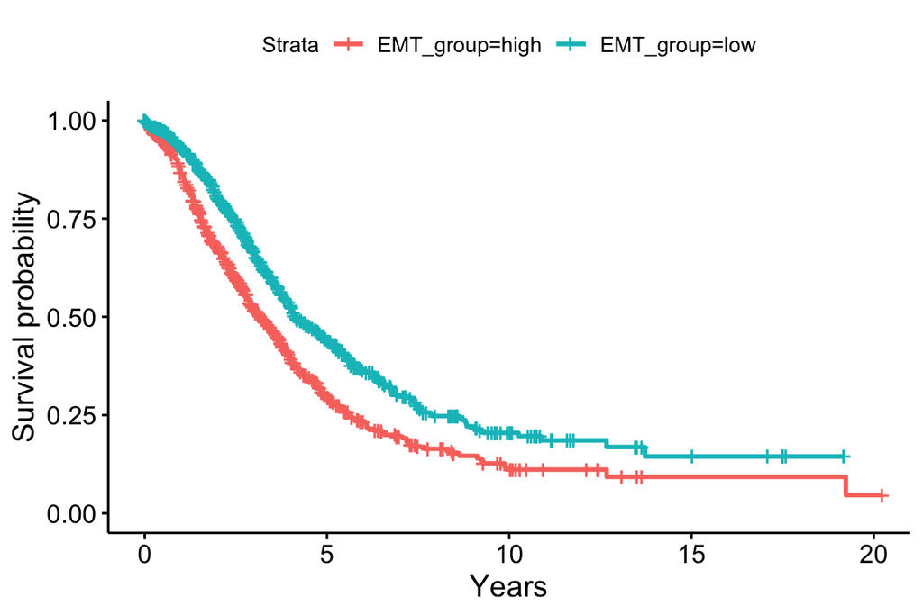

```r
fit1 <- survfit(y~EMT_group, data = df_all)
ggsurvplot(fit1, data = df_all, pval = F) + xlab("Years")
```

```r
# ggsave("../revision_plots/main/20191009_survival_pooled_nine.png", width = 5, height = 4)
```

# 9 AOCS: Grade & ciliated cells

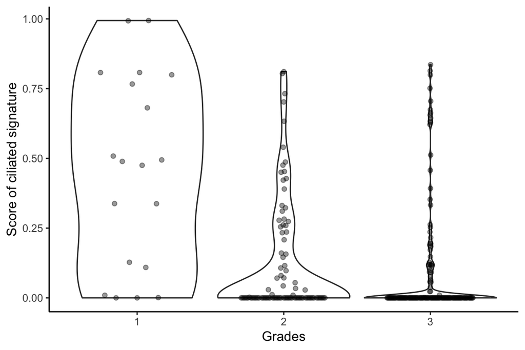

```r
toteset$ciliated.new <- svr_fit_tot[,"ciliated"]
ggplot(as.data.frame(pData(toteset))[!is.na(toteset$grade),], aes(x = as.factor(grade), y = ciliated.new)) + geom_violin(scale = "width") + theme_classic() + geom_quasirandom(alpha = 0.4, width = 0.3) +
  xlab("Grades")+ ylab("Score of ciliated signature")
```

```r
# ggsave("plots/20190215AOCS_grade_ciliated.pdf", width = 4, height = 3)
```

```r
wilcox.test(toteset$ciliated.new[toteset$grade == 1], toteset$ciliated.new[toteset$grade > 1], alternative = "greater")
```

```
##
##  Wilcoxon rank sum test with continuity correction
##
## data:  toteset$ciliated.new[toteset$grade == 1] and toteset$ciliated.new[toteset$grade > 1]
## W = 4141, p-value = 7.858e-09
## alternative hypothesis: true location shift is greater than 0
```

# 10 Save data

```r
# saveRDS(eset, "../../scFT-paper_rds/20191009_esetTCGA_afterDeconvolution.rds")
# write.csv(sig_matrix_new, "../../scFT-paper_rds/sig_matrix_new20200109.csv")
```

# 11 Technical

```r
# R version 3.5.2 (2018-12-20)
# Platform: x86_64-apple-darwin15.6.0 (64-bit)
# Running under: macOS Mojave 10.14.4
#
# Matrix products: default
# BLAS: /System/Library/Frameworks/Accelerate.framework/Versions/A/Frameworks/vecLib.framework/Versions/A/libBLAS.dylib
# LAPACK: /Library/Frameworks/R.framework/Versions/3.5/Resources/lib/libRlapack.dylib
#
# locale:
# [1] en_US.UTF-8/en_US.UTF-8/en_US.UTF-8/C/en_US.UTF-8/en_US.UTF-8
#
# attached base packages:
# [1] stats4    parallel  stats     graphics  grDevices utils     datasets  methods   base
#
# other attached packages:
#  [1] RColorBrewer_1.1-2          edgeR_3.24.3                limma_3.38.3                viridis_0.5.1               viridisLite_0.3.0
#  [6] ggrepel_0.8.0               ggbeeswarm_0.6.0            scater_1.10.1               SingleCellExperiment_1.4.1  SummarizedExperiment_1.12.0
# [11] DelayedArray_0.8.0          BiocParallel_1.16.5         matrixStats_0.54.0          GenomicRanges_1.34.0        GenomeInfoDb_1.18.1
# [16] powerSurvEpi_0.1.0          survival_2.43-3             survminer_0.4.3             ggpubr_0.2                  magrittr_1.5
# [21] ggplot2_3.2.0.9000          preprocessCore_1.44.0       e1071_1.7-0.1               xbioc_0.1.15                AnnotationDbi_1.44.0
# [26] IRanges_2.16.0              S4Vectors_0.20.1            MASS_7.3-51.1               bseqsc_1.0                  Biobase_2.42.0
# [31] BiocGenerics_0.28.0         csSAM_1.4                   Rcpp_1.0.0
#
# loaded via a namespace (and not attached):
#   [1] colorspace_1.4-0         class_7.3-15             modeltools_0.2-22        mclust_5.4.2             XVector_0.22.0
#   [6] rstudioapi_0.9.0         flexmix_2.3-14           bit64_0.9-7              mvtnorm_1.0-8            codetools_0.2-16
#  [11] splines_3.5.2            doParallel_1.0.14        robustbase_0.93-3        knitr_1.21               Formula_1.2-3
#  [16] broom_0.5.1              gridBase_0.4-7           km.ci_0.5-2              cluster_2.0.7-1          kernlab_0.9-27
#  [21] pheatmap_1.0.12          HDF5Array_1.10.1         compiler_3.5.2           rvcheck_0.1.3            backports_1.1.3
#  [26] assertthat_0.2.0         Matrix_1.2-15            lazyeval_0.2.1           htmltools_0.3.6          tools_3.5.2
#  [31] bindrcpp_0.2.2           gtable_0.2.0             glue_1.3.0               GenomeInfoDbData_1.2.0   reshape2_1.4.3
#  [36] dplyr_0.7.8              NMF_0.22                 trimcluster_0.1-2.1      nlme_3.1-137             iterators_1.0.10
#  [41] fpc_2.1-11.1             DelayedMatrixStats_1.4.0 xfun_0.4                 stringr_1.4.0            rngtools_1.3.1
#  [46] dendextend_1.9.0         DEoptimR_1.0-8           zlibbioc_1.28.0          zoo_1.8-4                scales_1.0.0
#  [51] BiocInstaller_1.32.1     rhdf5_2.26.2             yaml_2.2.0               memoise_1.1.0            gridExtra_2.3
#  [56] KMsurv_0.1-5             pkgmaker_0.27            stringi_1.2.4            RSQLite_2.1.1            foreach_1.4.4
#  [61] bibtex_0.4.2             rlang_0.4.0              pkgconfig_2.0.2          prabclus_2.2-7           bitops_1.0-6
#  [66] evaluate_0.13            lattice_0.20-38          Rhdf5lib_1.4.2           purrr_0.3.0              bindr_0.1.1
#  [71] labeling_0.3             cmprsk_2.2-7             cowplot_0.9.4            bit_1.1-14               tidyselect_0.2.5
#  [76] plyr_1.8.4               R6_2.3.0                 generics_0.0.2           DBI_1.0.0                pillar_1.3.1
#  [81] whisker_0.3-2            withr_2.1.2              RCurl_1.95-4.11          nnet_7.3-12              tsne_0.1-3
#  [86] tibble_2.0.1             crayon_1.3.4             survMisc_0.5.5           rmarkdown_1.11           locfit_1.5-9.1
#  [91] grid_3.5.2               data.table_1.12.0        blob_1.1.1               digest_0.6.18            diptest_0.75-7
#  [96] xtable_1.8-3             tidyr_0.8.2              gridGraphics_0.3-0       munsell_0.5.0            ggplotify_0.0.3
# [101] beeswarm_0.2.3           registry_0.5             vipor_0.4.5
```